# 521 - Computer Platforms for Data Science

### Master of Data Science 2021

[figure not shown]

[The Turing Way Community, & Scriberia. (2020). Illustrations from the Turing Way book dashes](https://doi.org/10.5281/zenodo.3695300)

### Welcome!

Florencia D'Andrea  
**Mail** fdandrea@cs.ubc.ca  
**Slack channel** #5  
**Office hours** Fridays

[figure not shown]

## Support

- Joel Ostblom

After this lecture you will be able to:

- Launch JupyterLab via Canvas to use MDS's cloud instance
- Use the Notebook interface inside Jupyterlab
- Know your way around the JupyterLab user interface

After this lecture you will be able to:

- Launch JupyterLab via Canvas to use MDS's cloud instance
- Use the Notebook interface inside Jupyterlab
- Know your way around the JupyterLab user interface

### What is JupyterLab?

[figure not shown]

### integrated development environment (IDE)

Provide all the tools you need in one place

[figure not shown]

### Jupyter Lab

### How to access Jupyter Lab?

(1) [UBC Server](https://ubc.syzygy.ca/) | (2) Installed version on your computer

[figure not shown]

After this lecture you will be able to:

- Launch JupyterLab via Canvas to use MDS's cloud instance
- Use the Notebook interface inside Jupyterlab
- Know your way around the JupyterLab user interface

### Using Jupyter Notebooks

The Notebook provides and interface where you can mix text, code, mathematical expressions, plots, videos, and more, all in the same file.

[figure not shown]

### Live Demo

[figure not shown]

[The Turing Way Community, & Scriberia (2020)](https://doi.org/10.5281/zenodo.3695300)

### Topbar

### Reproducibility of Jupyter Notebooks

```python
a = 5
```

### Markdown

### Static figure creation

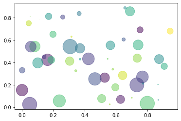

```python
# Please note, you don't have to understand what is going on in this cell
# it is just to show you how a static plot looks inside JupyterLab

import numpy as np
import matplotlib.pyplot as plt

N = 50
x = np.random.rand(N)
y = np.random.rand(N)
colors = np.random.rand(N)
area = (30 * np.random.rand(N))**2  # 0 to 15 point radii

plt.scatter(x, y, s=area, c=colors, alpha=0.5)
```

### Exporting notebooks

After this lecture you will be able to:

- Launch JupyterLab via Canvas to use MDS's cloud instance
- Use the Notebook interface inside Jupyterlab
- Know your way around the JupyterLab user interface

### How to get help in the notebook

[figure not shown]

[gif extracted from Language Server Protocol integration for Jupyter(Lab)](https://github.com/krassowski/jupyterlab-lsp)

```python
math.
```